# Smart Street Lighting Efficiency

**Use Case:** Project 30 – Smart Street Lighting Efficiency  
**Team:** Binul Bijo and Kliona Kennet  
**Purpose:** This notebook demonstrates how streetlight, traffic, and pedestrian datasets can be combined to identify lighting efficiency patterns and generate practical recommendations.

## Scenario

Cities often operate streetlights using static schedules, even though traffic and pedestrian activity changes across the day. This can cause some periods to be **over-lit**, where lighting is higher than needed, and other periods to be **under-lit**, where high activity may require stronger lighting support.

This use case explores how real Melbourne urban datasets can support smarter lighting decisions by analysing hourly activity patterns.

## What this use case demonstrates

By the end of this notebook, the project demonstrates:

- Loading and inspecting three project datasets
- Cleaning streetlight, traffic, and pedestrian data
- Creating hourly traffic and pedestrian activity measures
- Integrating datasets using a time-based approach
- Creating a weighted demand score
- Classifying lighting conditions as **over-lit**, **efficient**, or **under-lit**
- Generating recommendation analysis for smart lighting decisions
- Saving final outputs and visualisations as project evidence

## Datasets used

This use case uses three datasets:

1. **Street Light Locations dataset** – provides lighting infrastructure information, including location and emitted lux levels.
2. **Traffic Flow dataset** – provides vehicle movement data that is used to calculate hourly traffic activity.
3. **Pedestrian Counting dataset** – provides hourly pedestrian counts from Melbourne sensors.

Because the datasets do not share a perfect common spatial key, the integration is performed using an **hourly activity approach**. This is suitable for showing how lighting demand changes across the day.

## 1. Importing packages

This section imports the Python libraries needed for data handling, numerical operations, visualisation, and saving output files.

```python
import pandas as pd
import numpy as np
import matplotlib.pyplot as plt
import os
```

## 2. Creating output folder

The output folder stores generated charts and the final CSV summary. This makes the notebook evidence easier to upload to GitHub and use in the final submission.

```python
os.makedirs("outputs", exist_ok=True)
```

## 3. Loading datasets

This section loads the three CSV files into pandas DataFrames. The shape and column names are printed to verify that the datasets have loaded correctly and to understand their structure before cleaning.

```python
street = pd.read_csv("streetlight.csv")
traffic = pd.read_csv("traffic.csv")
ped = pd.read_csv("pedestrian.csv")

print("Streetlight dataset shape:", street.shape)
print("Traffic dataset shape:", traffic.shape)
print("Pedestrian dataset shape:", ped.shape)

print("\nStreetlight columns:")
print(street.columns.tolist())

print("\nTraffic columns:")
print(traffic.columns.tolist())

print("\nPedestrian columns:")
print(ped.columns.tolist())
```

```
Streetlight dataset shape: (106037, 21)
Traffic dataset shape: (60168, 28)
Pedestrian dataset shape: (1472102, 9)

Streetlight columns:
['Geo Point', 'Geo Shape', 'prop_id', 'name', 'addresspt1', 'xorg', 'ext_id', 'asset_clas', 'label', 'asset_type', 'easting', 'northing', 'str_id', 'addresspt_', 'asset_subt', 'xsource', 'profile', 'xdate', 'xdrawing', 'mcc_id', 'roadseg_id']

Traffic columns:
['date', 'road_name', 'location', 'suburb', 'speed_limit', 'direction', 'time', 'vehicle_class_1', 'vehicle_class_2', 'vehicle_class_3', 'vehicle_class_4', 'vehicle_class_5', 'vehicle_class_6', 'vehicle_class_7', 'vehicle_class_8', 'vehicle_class_9', 'vehicle_class_10', 'vehicle_class_11', 'vehicle_…

Pedestrian columns:
['ID', 'Location_ID', 'Sensing_Date', 'HourDay', 'Direction_1', 'Direction_2', 'Total_of_Directions', 'Sensor_Name', 'Location']
```

## 4. Streetlight data cleaning

The streetlight dataset includes a `Geo Point` column containing latitude and longitude together. This step separates the coordinates, converts them into numeric values, removes missing coordinate records, and calculates key summary measures such as total streetlights and average lux level.

```python
street[['latitude', 'longitude']] = street['Geo Point'].str.split(',', expand=True)

street['latitude'] = pd.to_numeric(street['latitude'], errors='coerce')
street['longitude'] = pd.to_numeric(street['longitude'], errors='coerce')

# Drop rows with missing coordinates
street_clean = street.dropna(subset=['latitude', 'longitude']).copy()

print("\nCleaned streetlight dataset shape:", street_clean.shape)

# Basic streetlight stats
streetlight_count = len(street_clean)
avg_lux = street_clean['label'].mean()

print("Total streetlights:", streetlight_count)
print("Average lux level:", avg_lux)
```

```
Cleaned streetlight dataset shape: (106037, 23)
Total streetlights: 106037
Average lux level: 15.044991738732708
```

### Streetlight lux distribution

This histogram shows the distribution of emitted lux levels. It helps identify whether most streetlights have similar lighting levels or whether there are unusually high or low values that may affect efficiency.

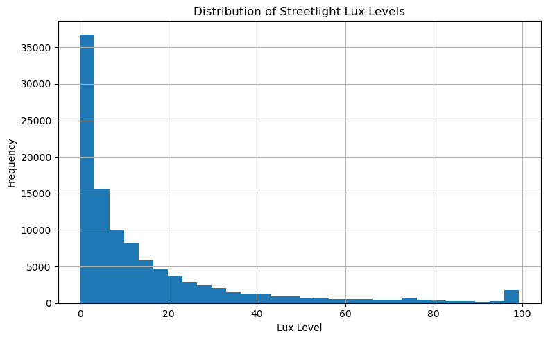

```python
plt.figure(figsize=(8,5))
street_clean['label'].dropna().hist(bins=30)
plt.title("Distribution of Streetlight Lux Levels")
plt.xlabel("Lux Level")
plt.ylabel("Frequency")
plt.tight_layout()
plt.savefig("outputs/streetlight_lux_distribution.png")
plt.show()
```

### Streetlight concentration by road segment

[figure not shown]

```python
top_segments = street_clean['roadseg_id'].value_counts().head(10)

plt.figure(figsize=(10,5))
top_segments.plot(kind='bar')
plt.title("Top 10 Road Segments by Number of Streetlights")
plt.xlabel("Road Segment ID")
plt.ylabel("Count of Streetlights")
plt.tight_layout()
plt.savefig("outputs/top_road_segments_streetlights.png")
plt.show()
```

## 5. Traffic data cleaning

The traffic dataset contains multiple vehicle class columns. This step identifies all vehicle-related columns and prepares them for calculating a single total vehicle count.

```python
vehicle_cols = [col for col in traffic.columns if "vehicle" in col.lower()]

print("\nVehicle columns found:")
print(vehicle_cols)
```

```
Vehicle columns found:
['vehicle_class_1', 'vehicle_class_2', 'vehicle_class_3', 'vehicle_class_4', 'vehicle_class_5', 'vehicle_class_6', 'vehicle_class_7', 'vehicle_class_8', 'vehicle_class_9', 'vehicle_class_10', 'vehicle_class_11', 'vehicle_class_12', 'vehicle_class_13']
```

### Creating total vehicle count

All vehicle class columns are summed into `total_vehicles`. This creates one clear traffic activity measure for each record.

```python
traffic['total_vehicles'] = traffic[vehicle_cols].sum(axis=1, skipna=True)
```

### Extracting hourly traffic activity

The time column is converted into an hour value so traffic can be analysed by hour of the day. Rows without valid hour information are removed to keep the analysis reliable.

```python
if 'date' in traffic.columns:
    traffic['date'] = pd.to_datetime(traffic['date'], errors='coerce')

if 'time' in traffic.columns:
    traffic['hour'] = pd.to_datetime(traffic['time'], format='%H:%M', errors='coerce').dt.hour
elif 'hour' in traffic.columns:
    traffic['hour'] = pd.to_numeric(traffic['hour'], errors='coerce')
else:
    raise ValueError("No suitable time/hour column found in traffic.csv")

print("\nTraffic data sample:")
print(traffic[['total_vehicles', 'hour']].head())
```

```
Traffic data sample:
   total_vehicles  hour
0             0.0     3
1             7.0    20
2             0.0     1
3             6.0    11
4             3.0     6
```

```python
traffic_clean = traffic.dropna(subset=['hour']).copy()
traffic_clean['hour'] = traffic_clean['hour'].astype(int)
```

```python
print("Cleaned traffic dataset shape:", traffic_clean.shape)
```

```
Cleaned traffic dataset shape: (60168, 30)
```

## 6. Traffic visualisation

The traffic data is grouped by hour to calculate the average vehicle count for each hour. This helps identify peak and low traffic periods.

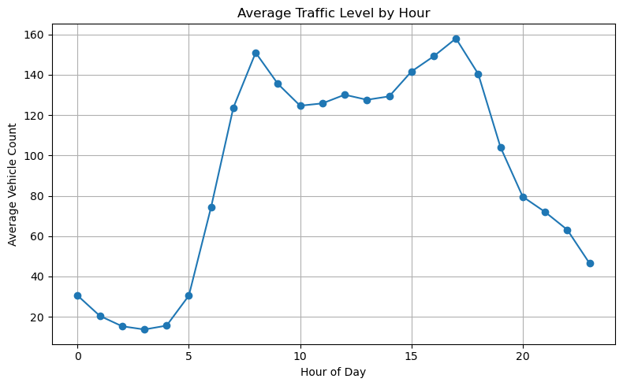

```python
traffic_hour = traffic_clean.groupby('hour')['total_vehicles'].mean().reset_index()
traffic_hour.rename(columns={'total_vehicles': 'traffic_level'}, inplace=True)

plt.figure(figsize=(8,5))
plt.plot(traffic_hour['hour'], traffic_hour['traffic_level'], marker='o')
plt.title("Average Traffic Level by Hour")
plt.xlabel("Hour of Day")
plt.ylabel("Average Vehicle Count")
plt.grid(True)
plt.tight_layout()
plt.savefig("outputs/traffic_by_hour.png")
plt.show()
```

### Optional traffic road analysis

If road names are available, this chart shows the roads with the highest total vehicle counts. This is useful for understanding where major traffic activity is concentrated.

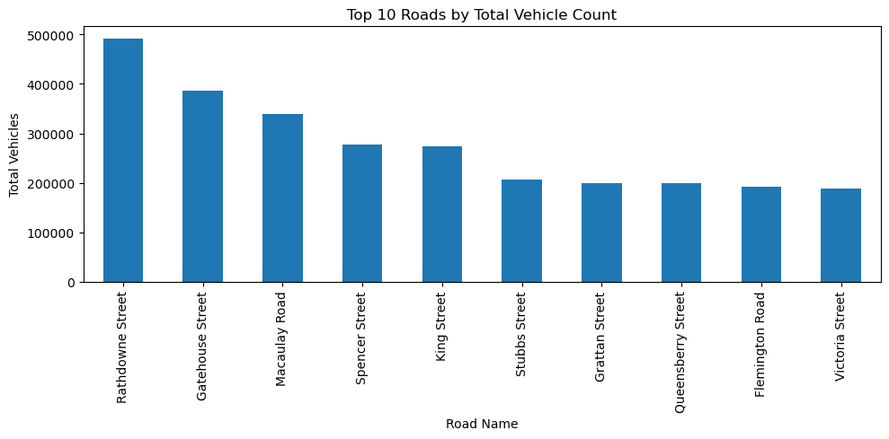

```python
if 'road_name' in traffic_clean.columns:
    top_roads = traffic_clean.groupby('road_name')['total_vehicles'].sum().sort_values(ascending=False).head(10)

    plt.figure(figsize=(10,5))
    top_roads.plot(kind='bar')
    plt.title("Top 10 Roads by Total Vehicle Count")
    plt.xlabel("Road Name")
    plt.ylabel("Total Vehicles")
    plt.tight_layout()
    plt.savefig("outputs/top_traffic_roads.png")
    plt.show()
```

## 7. Pedestrian data cleaning

The pedestrian dataset uses `Sensing_Date`, `HourDay`, and `Total_of_Directions`. This step converts the date, hour, and pedestrian count fields into usable formats, then removes incomplete rows.

```python
print("Pedestrian columns:")
print(ped.columns.tolist())

ped.columns = ped.columns.str.strip()

ped['Sensing_Date'] = pd.to_datetime(ped['Sensing_Date'], errors='coerce')

ped['HourDay'] = pd.to_numeric(ped['HourDay'], errors='coerce')

ped['pedestrian_count'] = pd.to_numeric(ped['Total_of_Directions'], errors='coerce')

ped_clean = ped.dropna(subset=['Sensing_Date', 'HourDay', 'pedestrian_count']).copy()

ped_clean['hour'] = ped_clean['HourDay'].astype(int)

print("\nCleaned pedestrian dataset shape:", ped_clean.shape)
print("\nPedestrian cleaned sample:")
print(ped_clean[['Sensing_Date', 'hour', 'pedestrian_count', 'Sensor_Name', 'Location']].head())
```

```
Pedestrian columns:
['ID', 'Location_ID', 'Sensing_Date', 'HourDay', 'Direction_1', 'Direction_2', 'Total_of_Directions', 'Sensor_Name', 'Location']

Cleaned pedestrian dataset shape: (1472102, 11)

Pedestrian cleaned sample:
  Sensing_Date  hour  pedestrian_count Sensor_Name                    Location
0   2026-01-05     4                41      FliS_T  -37.81911705, 144.96558255
1   2024-08-12    23               378    Swa295_T  -37.81101524, 144.96429485
2   2024-09-11     4                23    Swa295_T  -37.81101524, 144.96429485
3   2025-09-07     1               591    Swa295_T  -37.81101524, 144.96429485
4   2024-11-07    17               680      RMIT_T  -37.80825648, 144.96304859
```

## 8. Pedestrian visualisation

The pedestrian data is grouped by hour to calculate average pedestrian activity. This shows when pedestrian movement is higher or lower throughout the day.

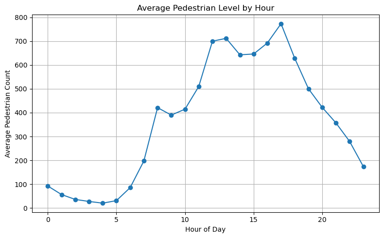

```python
ped_hour = ped_clean.groupby('hour')['pedestrian_count'].mean().reset_index()
ped_hour.rename(columns={'pedestrian_count': 'pedestrian_level'}, inplace=True)

plt.figure(figsize=(8,5))
plt.plot(ped_hour['hour'], ped_hour['pedestrian_level'], marker='o')
plt.title("Average Pedestrian Level by Hour")
plt.xlabel("Hour of Day")
plt.ylabel("Average Pedestrian Count")
plt.grid(True)
plt.tight_layout()
plt.savefig("outputs/pedestrian_by_hour.png")
plt.show()
```

## 9. Data integration

Traffic and pedestrian datasets are merged using the common `hour` column. This time-based integration was selected because the datasets do not align perfectly by exact location. Static streetlight summary features are then added to the merged activity dataset.

```python
merged_activity = traffic_hour.merge(ped_hour, on='hour', how='inner')

merged_activity['streetlight_count'] = streetlight_count
merged_activity['avg_lux'] = avg_lux

print("\nMerged activity data:")
print(merged_activity.head())
```

```
Merged activity data:
   hour  traffic_level  pedestrian_level  streetlight_count    avg_lux
0     0      30.529717         92.537110             106037  15.044992
1     1      20.445154         56.666506             106037  15.044992
2     2      15.305146         36.245961             106037  15.044992
3     3      13.698843         27.767305             106037  15.044992
4     4      15.617072         20.630454             106037  15.044992
```

## 10. Demand score calculation

A demand score is created to represent overall urban activity for each hour. Traffic is given a 60% weight and pedestrian activity is given a 40% weight. This reflects the assumption that vehicle movement has a slightly higher influence on road lighting demand, while pedestrian movement remains important for safety.

```python
merged_activity['demand_score'] = (
    merged_activity['traffic_level'] * 0.6 +
    merged_activity['pedestrian_level'] * 0.4
)
print("\nDemand score summary:")
print(merged_activity['demand_score'].describe())
```

```
Demand score summary:
count     24.000000
mean     201.881800
std      131.550594
min       17.622425
25%       73.005599
50%      226.958073
75%      334.791874
max      404.016515
Name: demand_score, dtype: float64
```

## 11. Efficiency classification

The demand score is split into three ranges using quantiles. Low-demand hours are classified as **over-lit**, high-demand hours are classified as **under-lit**, and middle-demand hours are classified as **efficient**. This makes the classification data-driven instead of manually choosing fixed thresholds.

```python
low_threshold = merged_activity['demand_score'].quantile(0.33)
high_threshold = merged_activity['demand_score'].quantile(0.66)
print("\nLow threshold:", low_threshold)
print("High threshold:", high_threshold)
def classify(row):
    if row['demand_score'] >= high_threshold:
        return "under-lit"
    elif row['demand_score'] <= low_threshold:
        return "over-lit"
    else:
        return "efficient"
merged_activity['efficiency'] = merged_activity.apply(classify, axis=1)
```

```
Low threshold: 128.23769237558594
High threshold: 265.5425818034572
```

## 12. Recommendation analysis

The recommendation logic converts each efficiency category into a practical action. Under-lit hours suggest increasing lighting, over-lit hours suggest reducing lighting, and efficient hours suggest maintaining the current setting.

```python
def recommend(row):
    if row['efficiency'] == "under-lit":
        return "Increase lighting during peak activity hours"
    elif row['efficiency'] == "over-lit":
        return "Reduce lighting during low activity hours"
    else:
        return "Lighting is optimal for current activity"
merged_activity['recommendation'] = merged_activity.apply(recommend, axis=1)
print("\nFinal efficiency and recommendation output:")
print(
    merged_activity[
        [
            'hour',
            'traffic_level',
            'pedestrian_level',
            'demand_score',
            'efficiency',
            'recommendation'
        ]
    ]
)
```

```
Final efficiency and recommendation output:
    hour  traffic_level  pedestrian_level  demand_score efficiency  \
0      0      30.529717         92.537110     55.332674   over-lit
1      1      20.445154         56.666506     34.933695   over-lit
2      2      15.305146         36.245961     23.681472   over-lit
3      3      13.698843         27.767305     19.326228   over-lit
4      4      15.617072         20.630454     17.622425   over-lit
5      5      30.508576         31.190856     30.781488   over-lit
6      6      74.432389         85.592852     78.896574   over-lit
7      7     123.749900        197.337836    153.185075  efficient
8      8     150.990028        421.065165    259.020083  efficient
9      9     135.509374        389.925675    237.275894  efficient
10    10     124.673714        414.695177    240.682299  efficient
11    11     125.838053        509.529459    279.314616  under-lit
12    12     130.120463        699.798749    357.991777  under-lit
```

[output cut: 37 more lines]

## 13. Final visualisations

The final graphs summarise the efficiency categories, demand score by hour, and the relationship between traffic and pedestrian activity. These outputs can be used as visual evidence in the project submission.

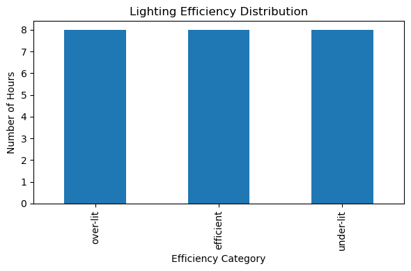

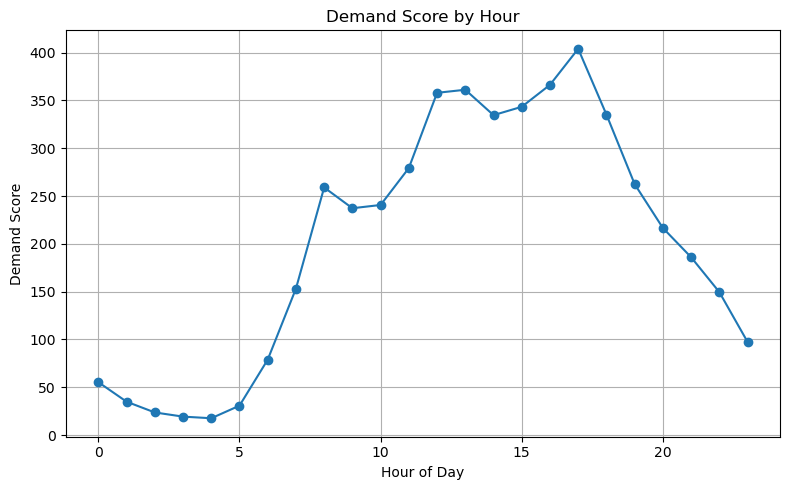

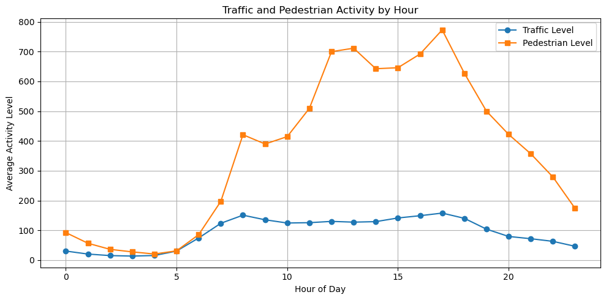

```python
plt.figure(figsize=(6,4))
merged_activity['efficiency'].value_counts().plot(kind='bar')
plt.title("Lighting Efficiency Distribution")
plt.xlabel("Efficiency Category")
plt.ylabel("Number of Hours")
plt.tight_layout()
plt.savefig("outputs/efficiency_distribution.png")
plt.show()
plt.figure(figsize=(8,5))
plt.plot(merged_activity['hour'], merged_activity['demand_score'], marker='o')
plt.title("Demand Score by Hour")
plt.xlabel("Hour of Day")
plt.ylabel("Demand Score")
plt.grid(True)
plt.tight_layout()
plt.savefig("outputs/demand_score_by_hour.png")
plt.show()
plt.figure(figsize=(10,5))
plt.plot(merged_activity['hour'], merged_activity['traffic_level'], marker='o', label='Traffic Level')
plt.plot(merged_activity['hour'], merged_activity['pedestrian_level'], marker='s', label='Pedestrian Level')
plt.title("Traffic and Pedestrian Activity by Hour")
plt.xlabel("Hour of Day")
plt.ylabel("Average Activity Level")
plt.legend()
plt.grid(True)
plt.tight_layout()
plt.savefig("outputs/activity_by_hour.png")
plt.show()
```

## 14. Saving final results

The final output table is saved as a CSV file. This provides a reusable project output showing hourly activity, demand score, efficiency classification, and recommendation.

```python
final_output = merged_activity[
    [
        'hour',
        'traffic_level',
        'pedestrian_level',
        'streetlight_count',
        'avg_lux',
        'demand_score',
        'efficiency',
        'recommendation'
    ]
]
final_output.to_csv("outputs/final_lighting_efficiency_summary.csv", index=False)
print("\nFinal output saved:")
print("outputs/final_lighting_efficiency_summary.csv")
```

```
Final output saved:
outputs/final_lighting_efficiency_summary.csv
```

## 15. Key observations

This final section summarises the main findings from the notebook in plain language, making the use case easier to understand without reading raw code.

```python
print("\nKey Observations:")
print("1. Traffic and pedestrian data were merged using hourly activity.")
print("2. Demand score combines traffic and pedestrian activity using 60% and 40% weights.")
print("3. Low-demand hours were classified as over-lit.")
print("4. High-demand hours were classified as under-lit.")
print("5. Medium-demand hours were classified as efficient.")
print("6. Recommendations were generated based on the efficiency category.")
```

```
Key Observations:
1. Traffic and pedestrian data were merged using hourly activity.
2. Demand score combines traffic and pedestrian activity using 60% and 40% weights.
3. Low-demand hours were classified as over-lit.
4. High-demand hours were classified as under-lit.
5. Medium-demand hours were classified as efficient.
6. Recommendations were generated based on the efficiency category.
```

## Limitations and future improvements

- The datasets do not share a perfect location-based key, so this version uses hourly integration.
- Future work can improve the model by linking streetlights to nearby traffic or pedestrian sensors using spatial nearest-neighbour methods.
- The 60/40 weighting can be refined using lighting standards, expert input, or validation data.
- A dashboard or map-based view can be added to make the final output more interactive.

## Team contribution summary

- **Binul Bijo:** Collected and cleaned the streetlight dataset, extracted location fields, calculated streetlight metrics, and created streetlight visualisations.
- **Kliona Kennet:** Collected and processed traffic and pedestrian datasets, created hourly activity features, integrated datasets, developed demand score, efficiency classification, and recommendation analysis.